# Prediction Demystified

### Jed Ludlow

`jedludlow.com`

# Objectives

## New to Prediction?

- Understand the essential terminology and concepts.
- Get ideas about where to go next.

## Experienced Data Scientist?

- A few philosophical things to consider.
- Implications of machine learning from an engineering perspective.

# Data Science

- A data scientist is a statistician who lives in San Francisco.
- Data science is statistics on a Mac.
- A data scientist is someone who is better at statistics than any software engineer and better at software engineering than any statistician.

(from https://twitter.com/jeremyjarvis/status/428848527226437632/photo/1)

# The Original Data Scientist

[figure not shown]

W. Edwards Deming

(source: Wikipedia)

# Control Charting is Prediction

[figure not shown]

(source: http://blog.minitab.com/blog/michelle-paret/control-charts-subgroup-size-matters)

# "Hello, World" Prediction Problem: Concept

*Predict* the *output variables* (height) as a function of the input *features* (age). Accomplish this by *fitting* a *model* (linear regression) to the available *samples* (five boys) in the *training* data set.

[figure not shown]

# "Hello, World" Prediction Problem: Python

```python
import numpy as np
from sklearn.linear_model import LinearRegression

# Training output samples
height_inches = np.array([[51.0, 56.0, 64.0, 71.0, 69.0]]).T

# Training feature samples
age_years = np.array([[7.8, 10.7, 13.7, 17.5, 20.1]]).T

# Initialize model
model = LinearRegression()

# Train
model.fit(age_years, height_inches)

# Predict
model.predict(15.0)
```

```
array([[ 63.90023465]])
```

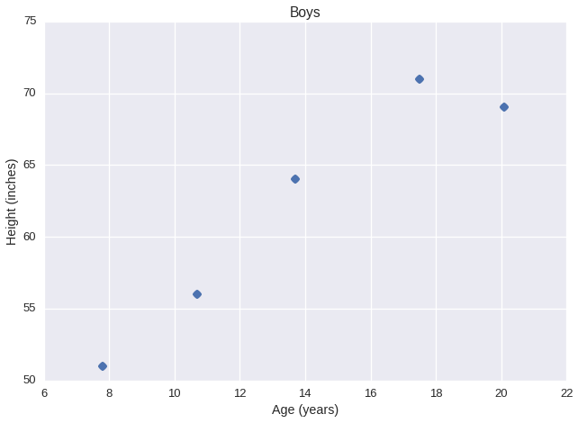

```python
plot_boys(age_years, height_inches);
```

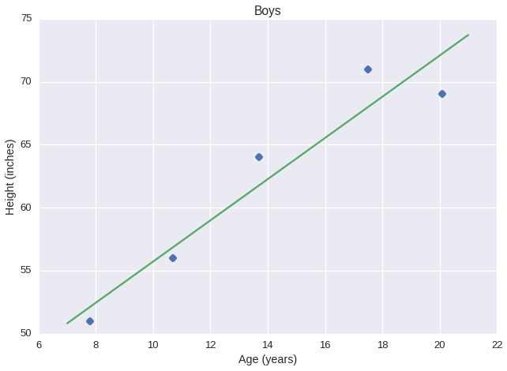

```python
plot_boys(age_years, height_inches, test, pred)
```

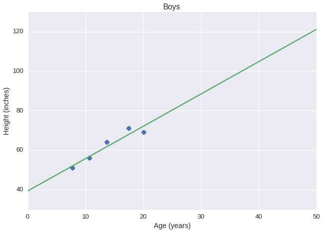

```python
plot_boys(age_years, height_inches, test, pred)
```

### Tall babies! Really tall adults!

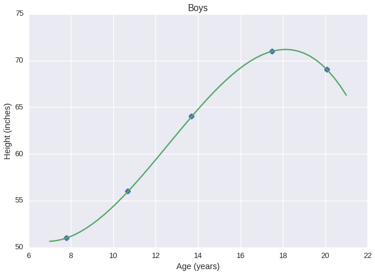

```python
plot_boys(age_years, height_inches, test, pred)
```

### Look! No training error!

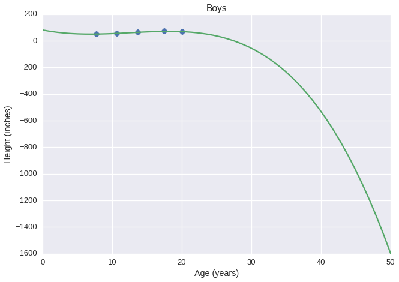

```python
plot_boys(age_years, height_inches, test, pred)
```

### Really tall babies! "Unphysical" heights for adults!

# Skillful Prediction

"I've beat this drum a hundred times, but what statistical models should do is to predict what will happen, given or conditioned on the data which came before and the premises which led to the particular model used. Then, since we have a prediction, we wait for confirmatory, never-observed-before data. If the model was good, we will have skillful predictions. If not, we start over."

-William M. Briggs, Statistician to the Stars!

(source: http://wmbriggs.com/post/14532)

# Lessons from "Hello, World" Prediction Problem

- Skillful prediction cannot be measured against the *training* data set. We must *test* against data not included in the *training*.
- Reducing the *training error* is not necessarily the primary objective of model development.
- A *flexible* model (polynomial regression) is not always better than an *inflexible* model (linear regression).
- *Extrapolation* beyond the bounds of the training data can produce unexpected results.

[figure not shown]

# Kaggle: Predicting Survival on the Titanic

- An introductory competition for knowledge sharing.
- Fully worked examples in Excel, Python, and R.
- Upload your solution to Kaggle for scoring.
- A great first example for a *classification* problem.

# Machine Learning Toolboxes

- Very popular open source packages available in many programming languages.
  - R
  - Python
- Growing number of "Machine Learning as a Service" companies.
- Big companies offering prediction APIs hosted in the cloud.
  - Microsoft Azure Machine Learning
  - Google Prediction API

# Titanic Training Set

```python
train_df = pd.read_csv("train.csv", dtype=dtypes)
train_df
```

|  | PassengerId | Survived | Pclass | Name | Sex | Age | SibSp | Parch | Ticket | Fare | Cabin | Embarked |
| --- | --- | --- | --- | --- | --- | --- | --- | --- | --- | --- | --- | --- |
| 0 | 1 | 0 | 3 | Braund, Mr. Owen Harris | male | 22 | 1 | 0 | A/5 21171 | 7.2500 | NaN | S |
| 1 | 2 | 1 | 1 | Cumings, Mrs. John Bradley (Florence Briggs Th... | female | 38 | 1 | 0 | PC 17599 | 71.2833 | C85 | C |
| 2 | 3 | 1 | 3 | Heikkinen, Miss. Laina | female | 26 | 0 | 0 | STON/O2. 3101282 | 7.9250 | NaN | S |
| 3 | 4 | 1 | 1 | Futrelle, Mrs. Jacques Heath (Lily May Peel) | female | 35 | 1 | 0 | 113803 | 53.1000 | C123 | S |
| 4 | 5 | 0 | 3 | Allen, Mr. William Henry | male | 35 | 0 | 0 | 373450 | 8.0500 | NaN | S |
| 5 | 6 | 0 | 3 | Moran, Mr. James | male | NaN | 0 | 0 | 330877 | 8.4583 | NaN | Q |
| 6 | 7 | 0 | 1 | McCarthy, Mr. Timothy J | male | 54 | 0 | 0 | 17463 | 51.8625 | E46 | S |
| 7 | 8 | 0 | 3 | Palsson, Master. Gosta Leonard | male | 2 | 3 | 1 | 349909 | 21.0750 | NaN | S |
| 8 | 9 | 1 | 3 | Johnson, Mrs. Oscar W (Elisabeth Vilhelmina Berg) | female | 27 | 0 | 2 | 347742 | 11.1333 | NaN | S |
| 9 | 10 | 1 | 2 | Nasser, Mrs. Nicholas (Adele Achem) | female | 14 | 1 | 0 | 237736 | 30.0708 | NaN | C |
| 10 | 11 | 1 | 3 | Sandstrom, Miss. Marguerite Rut | female | 4 | 1 | 1 | PP 9549 | 16.7000 | G6 | S |
| 11 | 12 | 1 | 1 | Bonnell, Miss. Elizabeth | female | 58 | 0 | 0 | 113783 | 26.5500 | C103 | S |
| 12 | 13 | 0 | 3 | Saundercock, Mr. William Henry | male | 20 | 0 | 0 | A/5. 2151 | 8.0500 | NaN | S |
| 13 | 14 | 0 | 3 | Andersson, Mr. Anders Johan | male | 39 | 1 | 5 | 347082 | 31.2750 | NaN | S |
| 14 | 15 | 0 | 3 | Vestrom, Miss. Hulda Amanda Adolfina | female | 14 | 0 | 0 | 350406 | 7.8542 | NaN | S |
| 15 | 16 | 1 | 2 | Hewlett, Mrs. (Mary D Kingcome) | female | 55 | 0 | 0 | 248706 | 16.0000 | NaN | S |
| 16 | 17 | 0 | 3 | Rice, Master. Eugene | male | 2 | 4 | 1 | 382652 | 29.1250 | NaN | Q |
| 17 | 18 | 1 | 2 | Williams, Mr. Charles Eugene | male | NaN | 0 | 0 | 244373 | 13.0000 | NaN | S |
| 18 | 19 | 0 | 3 | Vander Planke, Mrs. Julius (Emelia Maria Vande... | female | 31 | 1 | 0 | 345763 | 18.0000 | NaN | S |
| 19 | 20 | 1 | 3 | Masselmani, Mrs. Fatima | female | NaN | 0 | 0 | 2649 | 7.2250 | NaN | C |
| 20 | 21 | 0 | 2 | Fynney, Mr. Joseph J | male | 35 | 0 | 0 | 239865 | 26.0000 | NaN | S |
| 21 | 22 | 1 | 2 | Beesley, Mr. Lawrence | male | 34 | 0 | 0 | 248698 | 13.0000 | D56 | S |
| 22 | 23 | 1 | 3 | McGowan, Miss. Anna "Annie" | female | 15 | 0 | 0 | 330923 | 8.0292 | NaN | Q |
| 23 | 24 | 1 | 1 | Sloper, Mr. William Thompson | male | 28 | 0 | 0 | 113788 | 35.5000 | A6 | S |
| 24 | 25 | 0 | 3 | Palsson, Miss. Torborg Danira | female | 8 | 3 | 1 | 349909 | 21.0750 | NaN | S |
| 25 | 26 | 1 | 3 | Asplund, Mrs. Carl Oscar (Selma Augusta Emilia... | female | 38 | 1 | 5 | 347077 | 31.3875 | NaN | S |
| 26 | 27 | 0 | 3 | Emir, Mr. Farred Chehab | male | NaN | 0 | 0 | 2631 | 7.2250 | NaN | C |
| 27 | 28 | 0 | 1 | Fortune, Mr. Charles Alexander | male | 19 | 3 | 2 | 19950 | 263.0000 | C23 C25 C27 | S |
| 28 | 29 | 1 | 3 | O'Dwyer, Miss. Ellen "Nellie" | female | NaN | 0 | 0 | 330959 | 7.8792 | NaN | Q |
| 29 | 30 | 0 | 3 | Todoroff, Mr. Lalio | male | NaN | 0 | 0 | 349216 | 7.8958 | NaN | S |
| ... | ... | ... | ... | ... | ... | ... | ... | ... | ... | ... | ... | ... |
| 861 | 862 | 0 | 2 | Giles, Mr. Frederick Edward | male | 21 | 1 | 0 | 28134 | 11.5000 | NaN | S |
| 862 | 863 | 1 | 1 | Swift, Mrs. Frederick Joel (Margaret Welles Ba... | female | 48 | 0 | 0 | 17466 | 25.9292 | D17 | S |
| 863 | 864 | 0 | 3 | Sage, Miss. Dorothy Edith "Dolly" | female | NaN | 8 | 2 | CA. 2343 | 69.5500 | NaN | S |
| 864 | 865 | 0 | 2 | Gill, Mr. John William | male | 24 | 0 | 0 | 233866 | 13.0000 | NaN | S |
| 865 | 866 | 1 | 2 | Bystrom, Mrs. (Karolina) | female | 42 | 0 | 0 | 236852 | 13.0000 | NaN | S |
| 866 | 867 | 1 | 2 | Duran y More, Miss. Asuncion | female | 27 | 1 | 0 | SC/PARIS 2149 | 13.8583 | NaN | C |
| 867 | 868 | 0 | 1 | Roebling, Mr. Washington Augustus II | male | 31 | 0 | 0 | PC 17590 | 50.4958 | A24 | S |
| 868 | 869 | 0 | 3 | van Melkebeke, Mr. Philemon | male | NaN | 0 | 0 | 345777 | 9.5000 | NaN | S |
| 869 | 870 | 1 | 3 | Johnson, Master. Harold Theodor | male | 4 | 1 | 1 | 347742 | 11.1333 | NaN | S |
| 870 | 871 | 0 | 3 | Balkic, Mr. Cerin | male | 26 | 0 | 0 | 349248 | 7.8958 | NaN | S |
| 871 | 872 | 1 | 1 | Beckwith, Mrs. Richard Leonard (Sallie Monypeny) | female | 47 | 1 | 1 | 11751 | 52.5542 | D35 | S |
| 872 | 873 | 0 | 1 | Carlsson, Mr. Frans Olof | male | 33 | 0 | 0 | 695 | 5.0000 | B51 B53 B55 | S |
| 873 | 874 | 0 | 3 | Vander Cruyssen, Mr. Victor | male | 47 | 0 | 0 | 345765 | 9.0000 | NaN | S |
| 874 | 875 | 1 | 2 | Abelson, Mrs. Samuel (Hannah Wizosky) | female | 28 | 1 | 0 | P/PP 3381 | 24.0000 | NaN | C |
| 875 | 876 | 1 | 3 | Najib, Miss. Adele Kiamie "Jane" | female | 15 | 0 | 0 | 2667 | 7.2250 | NaN | C |
| 876 | 877 | 0 | 3 | Gustafsson, Mr. Alfred Ossian | male | 20 | 0 | 0 | 7534 | 9.8458 | NaN | S |
| 877 | 878 | 0 | 3 | Petroff, Mr. Nedelio | male | 19 | 0 | 0 | 349212 | 7.8958 | NaN | S |
| 878 | 879 | 0 | 3 | Laleff, Mr. Kristo | male | NaN | 0 | 0 | 349217 | 7.8958 | NaN | S |
| 879 | 880 | 1 | 1 | Potter, Mrs. Thomas Jr (Lily Alexenia Wilson) | female | 56 | 0 | 1 | 11767 | 83.1583 | C50 | C |
| 880 | 881 | 1 | 2 | Shelley, Mrs. William (Imanita Parrish Hall) | female | 25 | 0 | 1 | 230433 | 26.0000 | NaN | S |
| 881 | 882 | 0 | 3 | Markun, Mr. Johann | male | 33 | 0 | 0 | 349257 | 7.8958 | NaN | S |
| 882 | 883 | 0 | 3 | Dahlberg, Miss. Gerda Ulrika | female | 22 | 0 | 0 | 7552 | 10.5167 | NaN | S |
| 883 | 884 | 0 | 2 | Banfield, Mr. Frederick James | male | 28 | 0 | 0 | C.A./SOTON 34068 | 10.5000 | NaN | S |
| 884 | 885 | 0 | 3 | Sutehall, Mr. Henry Jr | male | 25 | 0 | 0 | SOTON/OQ 392076 | 7.0500 | NaN | S |
| 885 | 886 | 0 | 3 | Rice, Mrs. William (Margaret Norton) | female | 39 | 0 | 5 | 382652 | 29.1250 | NaN | Q |
| 886 | 887 | 0 | 2 | Montvila, Rev. Juozas | male | 27 | 0 | 0 | 211536 | 13.0000 | NaN | S |
| 887 | 888 | 1 | 1 | Graham, Miss. Margaret Edith | female | 19 | 0 | 0 | 112053 | 30.0000 | B42 | S |
| 888 | 889 | 0 | 3 | Johnston, Miss. Catherine Helen "Carrie" | female | NaN | 1 | 2 | W./C. 6607 | 23.4500 | NaN | S |
| 889 | 890 | 1 | 1 | Behr, Mr. Karl Howell | male | 26 | 0 | 0 | 111369 | 30.0000 | C148 | C |
| 890 | 891 | 0 | 3 | Dooley, Mr. Patrick | male | 32 | 0 | 0 | 370376 | 7.7500 | NaN | Q |

891 rows × 12 columns

# Prediction with Google Prediction API

- Initiate a project through Google Developers Console.
- Enable prediction API and cloud storage for that project.
- Upload training data (specially formatted CSV file) to the storage bucket.
- Install Google API Python Client.
- Get OAuth 2.0 authentication flow working. (Yes, really.)
- Call `insert` with appropriately formatted JSON to configure and train the model.
- Call `predict` with similarly formatted JSON to make predictions.
- Pay for training and prediction usage. (Free 60-day trial available.)

Luckily, there are good examples here: https://github.com/google/google-api-python-client

# Titanic Survival Model Using Google Prediction

- Fit a model to the Kaggle Titanic survival training set after some data cleaning.
- Model is live on Google's cloud services.
- Let's check training error by predicting back against a known survivor from the training set.

```python
pred = model.predict([[
    '1',  # Fare class
    'Spencer Mrs William Augustus Marie Eugenie',  # Name
    'female',  # Gender
    20.2,  # Age
    1,  # Number of parents or children aboard
    0,  # Number of siblings or spouse aboard
    146.5208,  # Fare price
    ],])

survived(pred)
```

```
YES
```

We could now make predictions for all the passengers in the *test set* and upload our solution to Kaggle for *scoring*, but it might be more fun....

[figure not shown]

```python
pred = model.predict([[
    '1',  # Fare class
    'Frank Lampard',  # Name
    'male',  # Gender
    36.0,  # Age
    0,  # Number of parents or children aboard
    0,  # Number of siblings or spouse aboard
    20.0,  # Fare price
    ],])
survived(pred)
```

```
NO
```

[figure not shown]

```python
pred = model.predict([[
    '1',  # Fare class
    'Frank Lampard',  # Name
    'male',  # Gender
    36.0,  # Age
    0,  # Number of parents or children aboard
    0,  # Number of siblings or spouse aboard
    500.0,  # Fare price
    ],])
survived(pred)
```

```
YES
```

# Lessons from Titanic Survival Classifier

- Real data is almost never tidy. Some cleaning is required.
- Some model types are by nature *black boxes* that cannot be inspected on the inside. You might be able to discern some things about how the model is behaving by feeding it interesting test cases, but that's not the same as having full access to the model internals.
- Choose the machine learning toolbox to match the modeling need *and* the implementation plan.

# Deep Learning

"Deep architectures are composed of multiple levels of non-linear operations, such as in neural nets with many hidden layers..."

-Yoshua Bengio, *Learning Deep Architectures for AI*

- Input *feature vectors* are very large. Thousands of features are common.
- The *model* is very *flexible*, sometimes employing millions of parameters.
- Training algorithms use sophisticated methods to avoid *over fitting*.
- Generally require serious hardware (GPU) to train in reasonable time.

# Convolutional Neural Networks

[figure not shown]

(source: http://deeplearning.net/tutorial/lenet.html#lenet)

# Records Were Made to Be Broken

[figure not shown]

(source: https://plus.google.com/113710395888978478005/posts/Gx3w9E14k2P)

[figure not shown]

(source: http://danielnouri.org/notes/2014/12/17/using-convolutional-neural-nets-to-detect-facial-keypoints-tutorial/)

# Validation

## What are the consequences of error in your predictions? Is safety paramount?

- Divide the available data into three sets:
  - *Training* set for base model training.
  - *Cross validation* set for model selection and parameter tuning.
  - *Test* set for estimating final accuracy.

## For measurements of skillful prediction, "...wait for confirmatory, never-observed-before data."

[figure not shown]

> “In the course of my work in the Potti lab, I discovered what I perceived to be problems in the predictor models that made it difficult for me to continue working in that environment,” he said in an email to The Cancer Letter.

(source: http://www.cancerletter.com/articles/20150109_1)

# Good Software Engineering Practice

[figure not shown]

(source: http://research.google.com/pubs/pub43146.html)

# Concluding Thoughts

- Most prediction problems can be described using a common framework of definitions. In that sense, they are not *mysterious*. But the latest deep learning models are bordering on magical!
- Seek the simplest possible model that attains the required level of prediction performance. Keep a close eye on your "technical debt" credit card bills.
- Validate, validate, and then keep validating.
- Choose your prediction problems wisely.
  - The existence of a large data set does not necessarily imply that a valuable model is lurking inside.
  - Chances are you don't yet have the data sets for the the most valuable problems. Getting that data will require concerted investment.

# Thank You!

### Jed Ludlow

`jedludlow.com`